# Basic analysis of your scRNA-seq data

Grigorii Nos

10/15/2019

## Pre-install necessary software

all of these packages depend on a bunch of another one, I cannot promise that you have all of them here in this list, so just feel free to shoot me email if you have errors

```r
if (!require("dplyr")) install.packages('dplyr')
if (!require("devtools")) install.packages('devtools')
if (!require('gProfileR')) install.packages('gProfileR')
if (!require('WriteXLS')) install.packages('WriteXLS')
if (!require("rimmi.rnaseq")) devtools::install_github(repo = 'GrigoriiNos/rimmi.rnaseq') # install my package
if (!require("Seurat")) devtools::install_version(package = 'Seurat', version = package_version('2.3.4')) # if this didn't work try this - source("https://z.umn.edu/archived-seurat")
```

```
## Note: As of version 1.0.0, cowplot does not change the
```

```
##   default ggplot2 theme anymore. To recover the previous
```

```
##   behavior, execute:
##   theme_set(theme_cowplot())
```

```r
library(Seurat)
library(rimmi.rnaseq)
library(gProfileR)
library(WriteXLS)
```

## loading the data

first of all you need to upload your R object, either click on it on your file system manager or run this command, specifying the path to the object that you want to analysie

```r
load('~/Desktop/RIMMI/Cre+:Cre- murine MLN+PP/E12/E12.RData')

E12
```

```
## An object of class seurat in project 10X_E12
##  16104 genes across 8256 samples.
```

Right after you’ve run that you gonna see the name of your sample in the global enviornment (top-left side) as Large seurt object Seurat object is storage of multiple cell-gene tables (raw, normalised ans scaled), different metadata about cells and genes and the output of the downstream analysis steps

## Take a first look at the data

When bioinformatition passes you the object, he already did QC, normalisation + scaling, dimensionality reduction and clustering, so you can call classis 2d scatter plot of your cells, to visualise clusters, you can have multiple clusterings with various resolutions stored in @meta.data slot.

If you tell R to show you meta data for each cell (rows = cell barcodes, columes - different features for the cells), you will see that there are one or several variables called res.0.6, or res.0.4, this is the output of the clustering in different resolutions, higher resolution is, more sensitive the clustering.

```r
head(E12@meta.data)
```

```
##                  nGene nUMI orig.ident percent.mito res.0.4
## AAACCCAAGACTCTTG   571 1536    10X_E12   0.01106771       2
## AAACCCAGTACAACGG  1259 2763    10X_E12   0.04596453       2
## AAACGCTCACCAGTTA  3213 8358    10X_E12   0.02045944       2
## AAAGAACTCGAGTCTA  1247 2340    10X_E12   0.02606838       2
## AAAGGATGTTCTCCAC  1853 4012    10X_E12   0.01620140       2
## AAAGGATGTTTGTTCT  2067 5362    10X_E12   0.01343284       2
##                          cellsnumbers res.0.7
## AAACCCAAGACTCTTG 4 cluster, 750 cells       4
## AAACCCAGTACAACGG 4 cluster, 750 cells       4
## AAACGCTCACCAGTTA 4 cluster, 750 cells       4
## AAAGAACTCGAGTCTA 3 cluster, 953 cells       3
## AAAGGATGTTCTCCAC 3 cluster, 953 cells       3
## AAAGGATGTTTGTTCT 4 cluster, 750 cells       4
```

## Plotting cells

Now lets make this plot

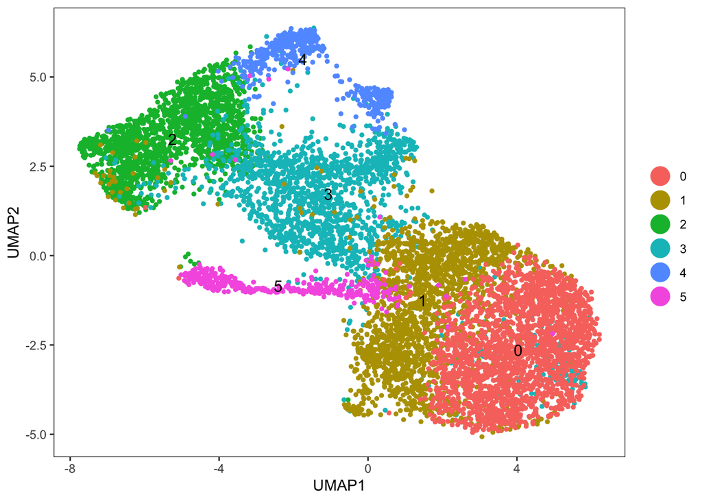

```r
# function for clustering visualisation
DimPlot(E12, # the name of the sample
        reduction.use = "umap", # what type of 2d dimensionality reduction we gonna use
        do.label = T, # tell the program that it needs to show cluster numbers on the plot
        group.by = 'res.0.4' # what resolution do you want for cell colouring? Change this parameter
)
```

## How to calculate new resolution

Let’s say you think that the current clustering that I pre-calculated is not detalied enough or vise versa, so you can calculate some more yourself, run this command. For instance you want to calculate clustering with resolution = 1

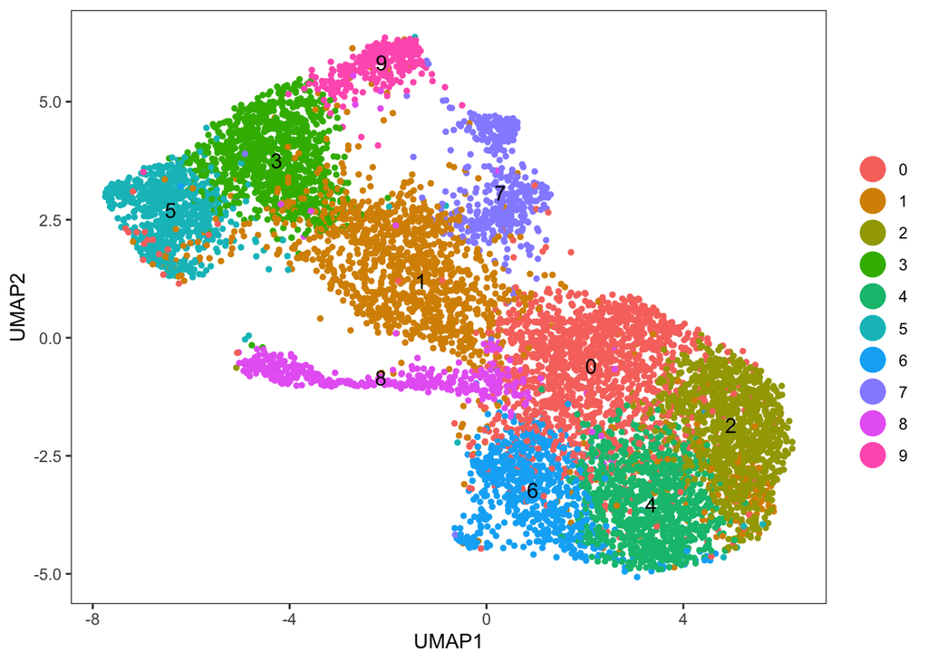

```r
dims <- E12@calc.params$RunUMAP$dims.use # please DON'T change this parameter, this is the minimum number or PCA dimensions that have maximum information preserved

# function for clustering calculation
E12 <- FindClusters(object = E12, # the sample name
                    reduction.type = "pca",
                    dims.use = dims,
                    resolution = 1, ###<<<<<### CHANGE THIS PARAMETER FOR RESOLUTION
                    print.output = 0,
                    save.SNN = TRUE,
                    force.recalc = T)

# function for clustering visualisation
DimPlot(E12,
        reduction.use = "umap",
        do.label = T,
        group.by = 'res.1' ### SPECIFY that now you want to change resolution on your plot
)
```

## Feature plots

When you want to plot an individual gene on your UMAP 2d plot, fun feature plot function

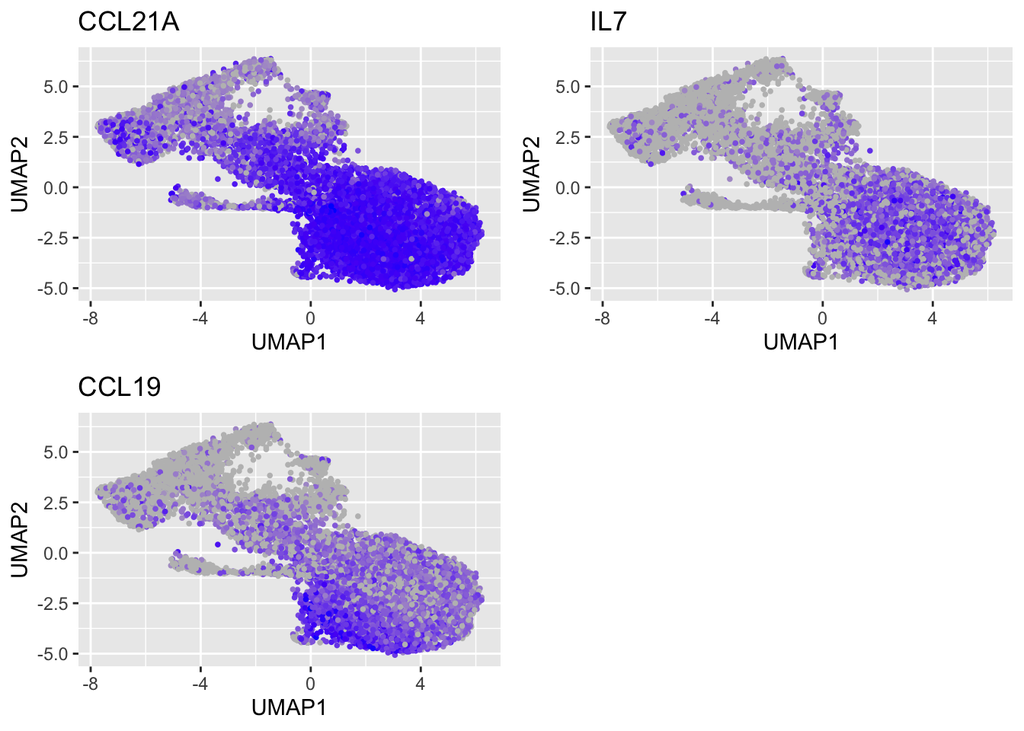

```r
# T-zone reticular cells?
FeaturePlot(object = E12, # sample name
            features.plot = c("CCL21A", "IL7", 'CCL19'),  # gene names, don't forget to add quotes and commas in the approptiate way, or you will have syntax errors
            cols.use = c("grey", "blue"), # colouts
            reduction.use = "umap")
```

## Do violin plots the same way

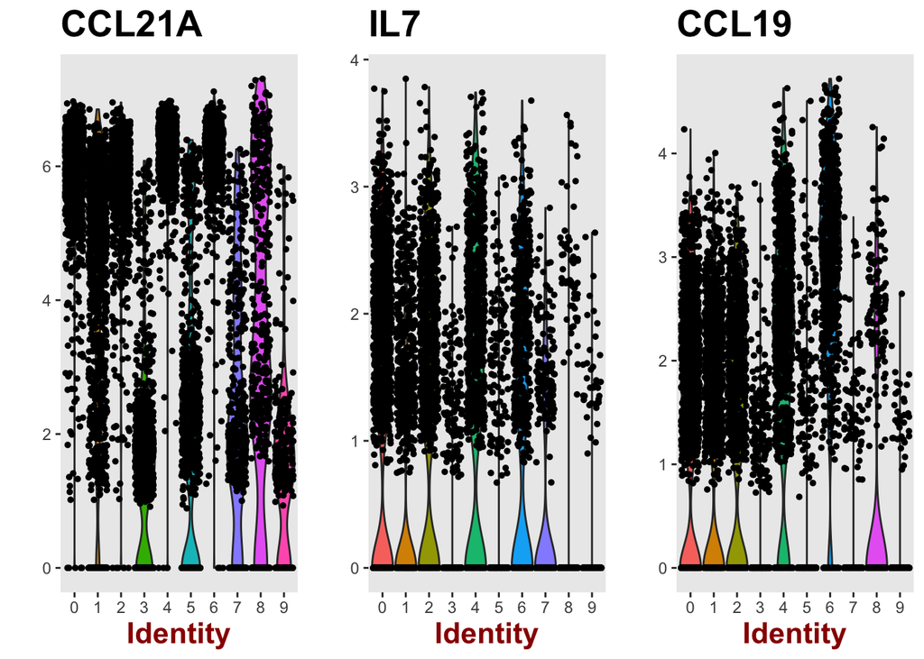

```r
# T-zone reticular cells?
VlnPlot(object = E12,
        features.plot = c("CCL21A", "IL7", 'CCL19'))
```

## Plot gene signatures

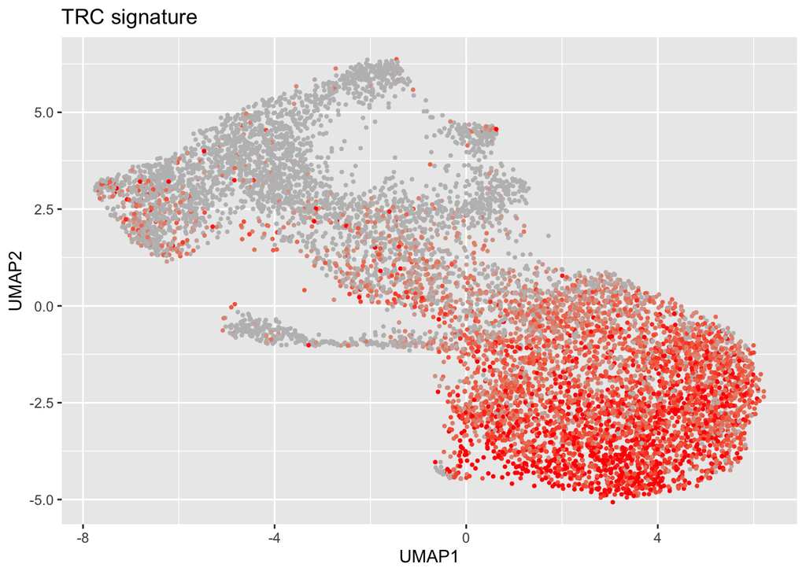

```r
# add new feature in the table as a average expression or several genes
E12 <- put_signature(markers = c("CCL19", "IL7", 'CXCL9', 'CCL21A', 'CXCL1'), # change genes names here
                     Seurat_obj = E12,
                     title =  'TRC signature'
)

# then plot it in the same way
FeaturePlot(object = E12,
            features.plot = 'TRC signature',
            cols.use = c("grey", "red"),
            reduction.use = "umap",
            min.cutoff = 'q10', # we set this parameter so only really high genes are marked with colour, because the average expression of multiple genes cannot be very low
            max.cutoff = 'q90')
```

## Re-calculate cluster markers

Now you can calculate markers for your new clusters and save them in the excel spreadsheet As a cluster marker we difuine genes that are differentially expressed between a given cluster and the rest of the cells in the sample.

You can see that the parameter only.pos is set as TRUE, meaning that you cauculate only positive markers.

```r
# calculate markers, this step can take some time, go and grab a cup of coffee
E12_markers <- FindAllMarkers(object = E12,
                              only.pos = TRUE, # <<<<<<< set as FALSE if you need negative markers
                              min.pct = 0.25,
                              thresh.use = 0.25)

# show the table in R with top 10 differentially expressed genes for each cluster
View(
  E12_markers %>%
    group_by(cluster) %>%
    top_n(10, avg_logFC)
)

# save the table in excel file, specify the path to your folder
rimmi.rnaseq::markers_to_xls(E12_markers, '~/Desktop/RIMMI/Cre+:Cre- murine MLN+PP/E12/blablabla')
```

## Functional analysis

Now you may want to do enrichment analysis for dufferent functions or pathways for your cluster markers, gene sets with pathway/function term are taken from all possible databases, such as GO, KEGG, reactome etc.

Make sure you are connected to the internet, otherwise this program won’t work

```r
annotation <- annotate_markers(markers_table = E12_markers,
                               organism = "mmusculus")
# shot top 10 for each clsuter
View(
  annotation %>%
    group_by(cluster) %>%
    top_n(10, p.value)
)

# save is as an excel shreadsheet
WriteXLS::WriteXLS(x = annotation,
                   ExcelFileName = "~/Desktop/RIMMI/Cre+:Cre- murine MLN+PP/E12/blablabla", # <<<<<<< specify file name
                   row.names = T
)
```

## Gene plots

You may want to check the relationships between 2 genes, for that you can use GenePlot function

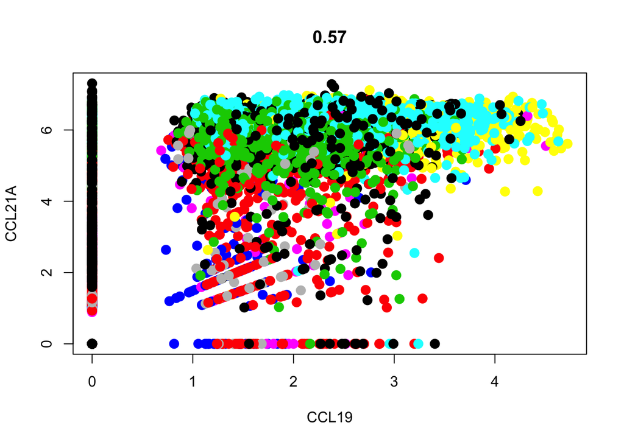

```r
GenePlot(object = E12,
         gene1 = "CCL19",
         gene2 = "CCL21A")
```

This is it so far. I will be adding new features if we come up with something, don’t forget that you can request some new functions if you have some idea of the analysis for your data!

Good luck!